# Trondheim Python Meetup

Today's sponsor

[figure not shown]

- Pizza
- Drinks from the bar (non-alcoholic)

# Previous Meetup

- Home Automation and IoT
- November 13, 2018
- ~30 attendees

[figure not shown]

```python
import IPython
url = 'https://ndcoslo.com/workshop/rapid-prototyping-for-iot/'
iframe = '<iframe src=' + url + ' width=900 height=550></iframe>'
IPython.display.HTML(iframe)
```

[interactive chart not shown]

```python
from IPython.display import HTML, display
display(HTML("""<table><tr><td><img src='images/Hans_Elias_B_Josephsen.jpeg' width=200>Hans Elias B. Josephsen</td>
<td><img src='images/morten.jpg' width=230>Morten Dille</td></tr></table>"""))
```

| Hans Elias B. Josephsen | Morten Dille |
| --- | --- |

# Future meetups

[figure not shown]

*26 April*

# Python productivity tips + mingling event

- cookiecutter
- python-fire
- other stuff

[figure not shown]

## Not included

- Virtual environments
- Anaconda
- Pandas
- ++

# Background

What should a Python project include?

[figure not shown]

- setup.py
- testing (pytest, nosetest, tox)
- linting (yapf, flake8, autopep8)
- docs (sphinx, markdown, rst)
- CLI (argparse, click)

[figure not shown]

A command-line utility that creates projects from cookiecutters (project templates)

https://github.com/audreyr/cookiecutter

### Installing

`pip install --user cookiecutter`

or

`conda install cookiecutter -c conda-forge`

## cookiecutter-pypackage

Cookiecutter template for a Python package.

https://github.com/audreyr/cookiecutter-pypackage

- Testing setup with unittest and python setup.py test or py.test
- Travis-CI: Ready for Travis Continuous Integration testing
- Tox testing: Setup to easily test for Python 2.7, 3.4, 3.5, 3.6
- Sphinx docs: Documentation ready for generation with, for example, ReadTheDocs
- Bumpversion: Pre-configured version bumping with a single command
- Auto-release to PyPI when you push a new tag to master (optional)
- Command line interface using Click (optional)

### Usage

`cookiecutter https://github.com/audreyr/cookiecutter-pypackage.git`

# Python Fire

Python Fire is a library for automatically generating command line interfaces (CLIs) from absolutely any Python object.

## Installation

`pip install fire`

or

`conda install fire -c conda-forge`

```python
import fire

class Calculator(object):
  """A simple calculator class."""

  def double(self, number):
    return 2 * number

if __name__ == '__main__':
  fire.Fire(Calculator)
```

`python calculator.py double 10` # 20

`python calculator.py double --number=15` # 30

- (- and _) are interchangeable
- mix python scripts with bash scripts

## Jupyter

- Presentations (RISE)
- nbextensions
- df.plot();
- ?str
- (12)

## Pycharm

- Hotkeys
- Macros

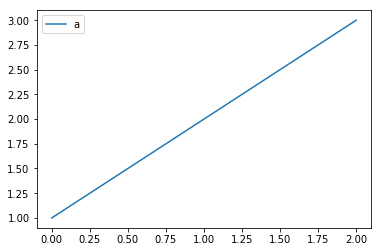

```python
%matplotlib inline
import pandas as pd

df = pd.DataFrame({'a': [1,2,3]})
df.plot()
```

# Mingling!

- What's your favorite productivity hack
- What's your favorite python package?
- Can I buy you a beer?